# Agricultura sustentable basada en datos en el estado de Sonora durante el siglo XXI

Rentabilidad de la producción de mango en Sonora

Equipo 5: Santana, Cazarez, Osuna, Urias

20/11/2021

# Sustentabilidad de la producción de Mango en Sonora, México

[figure not shown]

Inicio de cosecha de mango

## Introducción

Para este caso de estudio analizaremos el fruto del mango, su producción, cosecha, necesidades, basándonos en métodos estadísticos para saber su relación agrícola en el estado de Sonora, viendo lo que este estado puede cosechar y producir a lo largo de los años y veremos si vale la pena usar tantos recursos naturales para mantener la producción sustentable de este fruto y saber si sale rentable.

Veremos si la producción utiliza de buena manera la tierra, si los pasos necesarios se siguen correctamente para que la fruta pueda dar su máxima producción potencial. la tierra idónea y su mantenimiento son necesarias para este fruto, además de que debe tener un cierto clima que no lo dañe, y sobre todo que se mantenga limpio, sin basura, residuos ni desperdicios, una vez visto estos sigue la formación de la tierra para dejarlo en condiciones óptimas para su plantación, además de poner la siembra en lugares estratégicos para tener un máximo de potencial, y obviamente el mantenimiento de la planta, su cuidado constante, y precauciones del clima para poder producirlo de la mejor manera y finalmente enviarlo a comercializar.

## Antecedentes

Esta fruta es de climas cálidos. En 2019 se cosechó en 23 estados del país con un volumen de producción 11.9% mayor al de 2018. Sinaloa, Guerrero, Nayarit y Chiapas generan dos terceras partes del volumen cosechado a nivel nacional. Los mangos y aguacates exigen mucha agua, y hace tiempo que el agua no sobra. El Servicio de Información Agroalimentaria y Pesquera (SIAP), señala que este fruto se cosecha en 23 estados de la República Mexicana. Entre los principales productores se ubica Guerrero con un 22%, Nayarit con un 17% y Sinaloa con un 14%, que en conjunto suman el 53% de la producción nacional. El resto se proviene de Campeche, Chiapas, Colima, Jalisco, Michoacán, Oaxaca y Veracruz. Guerrero encabeza la lista gracias a su extensa superficie sembrada, así como al buen rendimiento del cultivo.

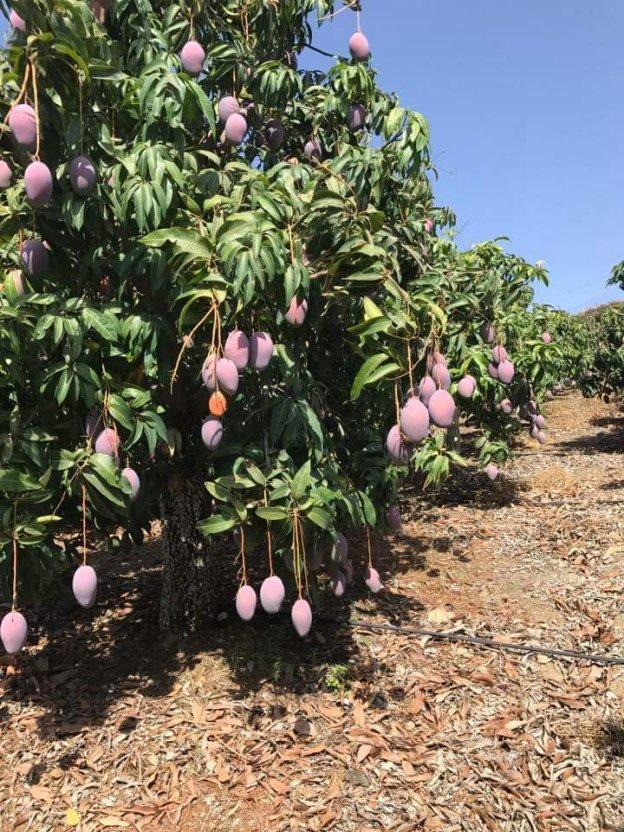

Granja de mango

## Objetivos del trabajo

¿Son los estados con climas más calurosos los que generan más dinero a raíz de la producción de mango? Podemos caer en la inferencia sobre que los lugares calurosos y con más luz son mejores para producir mango y generar más ingresos, pero es necesario analizar con los datos de los mangos y saber si esta condición les conviene a los agricultores de mango.

¿Cómo afecta la temperatura al mango en la agricultura? Es necesario saber si las temperaturas que cambian súbitamente afectan a las cosechas y como proteger estas de estos peligros, además de saber si es realmente importante la relación de la temperatura con la agricultura, ya que siempre se puede crear un espacio controlado, pero tendremos que valorar si vale la pena el costo

¿Al mango realmente le afecta el clima en Sonora? Debemos saber si Sonora realmente es viable para este cultivo, ya que se podría asignar la tierra utilizada de este, en vista de que es algo baja la cosecha, a tratar de plantar otro tipo de producto que pueda generar mayores ingresos

## Teoría

Se sabe por experiencia conocemos que todas las plantas necesitan ciertas cantidades de agua, así que es de suma importancia tener un buen sistema de riego y de alimentación, para aprovechar al máximo y eficientizar la necesidad de agua que ocupan las plantas, además de esto ocupan ciertas condiciones climatológicas ya que si sufren daños a causa de esto son más propensos a estropear la planta, encontramos máximas de 40ºC y mínimas de 0ºC. Los efectos de estas altas temperatura podrían empezar a verse a partir de los 35ºC, por ejemplo, con daños en la epidermis en el caso del mango.

México tiene una muy buena y rica posición geográfica para la agricultura teniendo grandes cantidades de sol, tierra, agua y viento para los cultivos, debido a esto es necesario que se optimicen los recursos lo mejor posible, pudiendo usar herramientas tecnológicas para automatizar muchos procesos haciéndolos relativamente más efectivos, además también los granjeros de todos los cultivos tienen que cuidarse del cambio climático ya que puede y va a afectar negativamente a muchos que principalmente basan su economía en cultivos.

Es realmente importante saber como tomar decisiones en base a los datos que tenemos ya que con estos podremos tomar decisiones sobre los procesos mucho mas seguros y así podemos deshacernos de la incertidumbre casi por completo al elegir un proceso en concreto.

En los últimos años, las tasas de crecimiento de la producción agropecuaria mundial y los rendimientos de los cultivos han disminuido. Esto ha suscitado temores de que el mundo no sea capaz de incrementar lo suficiente la producción de alimentos y otros productos para asegurar una alimentación adecuada de la población futura. La disminución no se ha producido a causa de la escasez de tierra o agua, sino más bien debido a que la demanda de productos agropecuarios ha disminuido. Las tasas de crecimiento de la población mundial han ido disminuyendo desde finales de los años sesenta y en muchos países se están alcanzando ahora niveles bastante altos de consumo de alimentos per cápita, por encima de los cuales incrementos adicionales serán limitados. Además, una parte persistentemente alta de la población mundial sigue sumida en una pobreza absoluta y carece de los ingresos necesarios para transformar sus necesidades en una demanda efectiva. (FAO.org. 2018)

## Metodología (métodos estadísticos que usan y también incluir los métodos de los datos)

## Operaciones

### Paquetes a utilizar

```r
library(pacman)
p_load(rmdformats, readr, readxl, ggplot2, plotly, DT, xfun, gridExtra, leaflet, GGally, psych, corrplot, cluster)
```

### Importando datos

- Producción de mangos por estado

```r
prodMango <- read_excel("ProduccionMangos.xlsx")
#View(prodMango)

sonoraMango <- read_excel("ProduccionSonoraMango.xlsx")
#View(sonoraMango)
```

- Temperaturas anuales por estado

```r
temp <- read_excel("TemperaturasPromAnualPorEstado.xlsx")
#View(temp)
```

### Visualizando los datos en tablas

- Tabla de producción de mangos

```r
datatable(prodMango)
```

|  | ENTIDAD | YEAR | SEMBRADA | COSECHADA | SINIESTRADA | PRODUCCION | RENDIMIENTO | PMR | VALORPRODUCCION |
| --- | --- | --- | --- | --- | --- | --- | --- | --- | --- |
| 1 | Baja California Sur | 2018 | 1557 | 1032 | 0 | 6698 | 6.49 | 5428.39 | 36359.36 |
| 2 | Campeche | 2018 | 2286.2 | 2223.5 | 0 | 31210.28 | 14.04 | 3756.78 | 117250.25 |
| 3 | Colima | 2018 | 4167.9 | 3841.85 | 0 | 58733.39 | 15.29 | 3676.64 | 215941.33 |
| 4 | Chiapas | 2018 | 38655.56 | 35509.16 | 0 | 279281.03 | 7.87 | 5198.86 | 1451941.81 |
| 5 | Durango | 2018 | 399.05 | 383.05 | 0 | 1598.85 | 4.17 | 4576.39 | 7316.96 |
| 6 | Guerrero | 2018 | 26393.65 | 24861.11 | 0 | 385125.02 | 15.49 | 5627.08 | 2167128.87 |
| 7 | Hidalgo | 2018 | 79 | 79 | 0 | 521.34 | 6.6 | 4163.4 | 2170.55 |
| 8 | Jalisco | 2018 | 7845.84 | 7772.84 | 0 | 114980.79 | 14.79 | 3186.29 | 366362.51 |
| 9 | México | 2018 | 364.5 | 361.5 | 0 | 2843.84 | 7.87 | 6034.21 | 17160.34 |
| 10 | Michoacán | 2018 | 25337.03 | 22343.34 | 0 | 160572.68 | 7.19 | 5860.28 | 941001.39 |

[output cut: 59 more lines]

- Tabla de temperaturas

```r
datatable(temp)
```

|  | ENTIDAD | AGUASCALIENTES | BAJA CALIFORNIA | BAJA CALIFORNIA SUR | CAMPECHE | COAHUILA | COLIMA | CHIAPAS | CHIHUAHUA | CIUDAD DE MÉXICO | DURANGO | GUANAJUATO | GUERRERO | HIDALGO | JALISCO | ESTADO DE MÉXICO | MICHOACÁN | MORELOS | NAYARIT | NUEVO LEÓN | OAXACA | PUEBLA | QUERÉTARO | QUINTANA ROO | SAN LUIS POTOSÍ | SINALOA | SONORA | TABASCO | TAMAULIPAS | … |
| --- | --- | --- | --- | --- | --- | --- | --- | --- | --- | --- | --- | --- | --- | --- | --- | --- | --- | --- | --- | --- | --- | --- | --- | --- | --- | --- | --- | --- | --- | --- |
| 1 | 2018 | 18.19166667 | 20.95833333 | 24.25 | 27.14166667 | 21.825 | 27.19166667 | 25.14166667 | 19.19166667 | 17.8 | 18.95833333 | 19.08333333 | 25.19166667 | 18.66666667 | 21.15833333 | 14.95833333 | 20.84166667 | 22.13333333 | 26.19166667 | 22 | 23.90833333 | 18.15833333 | 20.01666667 | 27.54166667 | 23.51666667 | 25.83333333 | 22.94166667 | 27.24166667 | 24.475 | … |
| 2 | 2019 | 18.8 | 19.9 | 23.7 | 27.7 | 22.4 | 27.4 | 25.6 | 18.9 | 18.8 | 18.9 | 19.8 | 25.5 | 19.8 | 21.8 | 15.6 | 21.2 | 22.4 | 26.5 | 22.6 | 24.2 | 19 | 20.9 | 28.1 | 24.5 | 25.8 | 22.4 | 27.6 | 25.1 | … |
| 3 | 2020 | 18.1 | 20.2 | 23.7 | 27.8 | 22.3 | 27.1 | 25.5 | 19.2 | 18.3 | 18.6 | 19.5 | 25.7 | 19.3 | 21.7 | 15.1 | 20.8 | 22.6 | 26.1 | 22.6 | 23.8 | 19.1 | 20.5 | 27.9 | 24.4 | 26.1 | 23.4 | 27.6 | 25.2 | … |

```r
mangoFrame <-data.frame(sonoraMango, check.names = F)
mangoFrame
```

```
##   YEAR SEMBRADA COSECHADA SINIESTRADA PRODUCCION RENDIMIENTO     PMR
## 1 2018    95.28        36           0     558.60       15.52 3761.60
## 2 2019    78.28        26           0     392.96       15.11 3490.11
## 3 2020   136.28        38           0     619.00       16.29 3793.54
##   VALORPRODUCCION TEMPERATURAANUAL
## 1         2101.23         22.94167
## 2         1371.47         22.40000
## 3         2348.20         23.40000
```

## Descarga de datos y código

### Descarga del código

```r
xfun::embed_file("ProyectoFinalAgricultura.Rmd")
```

Download ProyectoFinalAgricultura.Rmd

### Descarga los datos

```r
#Producción de mango
xfun::embed_file("ProduccionMangos.xlsx")
```

Download ProduccionMangos.xlsx

```r
#Temperaturas de México
xfun::embed_file("TemperaturasPromAnualPorEstado.xlsx")
```

Download TemperaturasPromAnualPorEstado.xlsx

## Bibliografía

SERVICIO DE INFORMACIÓN AGROALIMENTARIA Y PESQUERA (SIAP). (2020). Panorama Agroalimentario. México: Agricultura Secretaria de agricultura y desarrollo rural. Recuperado 21 de noviembre de 2021, de https://www.inforural.com.mx/wp-content/uploads/2020/11/Atlas-Agroalimentario-2020.pdf

Agricultura mundial: hacia los años 2015/2030. (s. f.). FAO.org. Recuperado 21 de noviembre de 2021, de https://www.fao.org/3/y3557s/y3557s03.htm

SAGARPA. (2017). Planeación Agrícola Nacional: Mango Mexicano 2017-2050. México: SAGARMA. https://www.gob.mx/cms/uploads/attachment/file/257078/Potencial-Mango.pdf

- Lugar de donde se sacaron los datos

http://infosiap.siap.gob.mx/gobmx/datosAbiertos.php

https://nube.siap.gob.mx/cierreagricola/

Metodología:

En este caso se trabajarán con estos métodos estadísticos

- Estadística descriptiva
- Correlación lineal
- Correlación lineal múltiple
- Análisis de normalidad de Shapiro-Wilk
- Correlación de pearson
- Regresión lineal simple
- Regresión lineal polinomios

¿Como nuestro caso de estudio influye a decisiones?

Valor de producción, trigo, CO2

## Teoría

- https://www.inforural.com.mx/wp-content/uploads/2020/11/Atlas-Agroalimentario-2020.pdf

Datos a tomar en cuenta

Sonora casi no cosecha nada de mango El clima en Sonora puede ser bueno para el mango hay falta de agua por eso casi no se cosecha